# Kirby Analysis Script (Using Functions)

## Data Setup

This is the correct script to setup the estimated parameter values for Kirby’s Monetary Choice Questionaire (1996).

#### Creating Rewards

```r
# subset and ignore NA's
kirby.test<-function.subset(kirby,kirby$small_amt)

# create reward groups
kirby.test$reward<-ifelse((kirby.test$large_amt>=75 & kirby.test$large_amt<=85),3,
                               ifelse((kirby.test$large_amt>=50 & kirby.test$large_amt<=60),2,1))

# check frequencies
with(kirby.test,table(worker_id,reward))
```

```
##                                       reward
## worker_id                              1 2 3
##   175c923b-6b6e-4fc1-9e17-4f912faaaa3a 9 9 9
##   24cc8fd3-7890-4683-974e-38ed3c645838 9 9 9
##   A07375212LC8D25XBGZ1J                9 9 9
##   A110KENBXU7SUJ                       9 9 9
##   A11YS0T8MV3Q7C                       9 9 9
##   A16ICTTBPD7Q6Y                       9 9 9
##   A16TESTJICU76L                       9 9 9
##   A1945USNZHTROX                       9 9 9
##   A1GYO6CJMVA9ZA                       9 9 9
##   A1IM92Q6UK32DV                       9 9 9
##   A1IQL14PO7OLJH                       9 9 9
##   A1NM7ZPZ3NH412                       9 9 9
##   A1OK974KXKO6FJ                       9 9 9
##   A1T9IKE8GV4LR4                       9 9 9
##   A2541C8MY0BYV3                       9 9 9
##   A2HHGI5CNSS5PD                       9 9 9
##   A2I3Y0L38HMQLZ                       9 9 9
##   A2NA2OJT15COZY                       9 9 9
##   A2OXXHGAM7B0Y                        9 9 9
##   A2RRBSTJ7H3G2B                       9 9 9
##   A2VM5D9YRFCM9W                       9 9 9
##   A2W59CL4UQ3S4S                       9 9 9
##   A2WGW5Y3ZFBDEC                       9 9 9
##   A2YKW761AK4ZGY                       9 9 9
##   A333STM8M95GJX                       9 9 9
##   A35EI6GDSC0EY8                       9 9 9
##   A366JCV00ETS7V                       9 9 9
##   A3EHI7J2E5DSJK                       9 9 9
##   A3NDYVCFCYRPT9                       9 9 9
##   A3UC45GKCAZ7ZU                       9 9 9
##   A40LU73SS18IW                        9 9 9
##   A6RHP75VV3265                        9 9 9
##   AAM0Q3DCSSQ0A                        9 9 9
##   ACRKDBKAS8GM1                        9 9 9
##   AT7THGIGM9XN5                        9 9 9
##   AW4AHMQ7EN4QI                        9 9 9
```

```r
kirby.test$key_press<-ifelse(kirby.test$key_press==80, 2, 1)
# smaller, sooner is 1 and larger, later is 2
```

#### Quality Checks

```r
# Flag any subects that may have chose immediate/delayed for all

kirby.test %>%
  group_by(worker_id) %>%
  summarise(freqdel=sum(key_press==2), freqimp=sum(key_press==1)) %>%
  filter(freqimp==length(kirby.test$key_press)/length(unique(kirby.test$worker_id))|freqdel==length(kirby.test$key_press)/length(unique(kirby.test$worker_id))) %>%
  select(worker_id) %>%
  unique()
```

```
## # A tibble: 1 × 1
##       worker_id
##          <fctr>
## 1 ACRKDBKAS8GM1
```

```r
# now, flag any subjects that answered all immediate or delayed for all trials in at least one of the reward sizes

kirby.test %>%
  group_by(worker_id, reward) %>%
  summarise(freqimp=sum(key_press==1), freqdel=sum(key_press==2)) %>%
   filter(freqimp==length(kirby.test$key_press)/(length(unique(kirby.test$worker_id))*length(unique(kirby.test$reward)))|freqdel==length(kirby.test$key_press)/(length(unique(kirby.test$worker_id))*length(unique(kirby.test$reward)))) %>%
  select(worker_id) %>%
  unique()
```

```
## Source: local data frame [7 x 1]
## Groups: worker_id [7]
##
##                              worker_id
##                                 <fctr>
## 1 24cc8fd3-7890-4683-974e-38ed3c645838
## 2                       A1IM92Q6UK32DV
## 3                       A1T9IKE8GV4LR4
## 4                       A2541C8MY0BYV3
## 5                       A3EHI7J2E5DSJK
## 6                        A6RHP75VV3265
## 7                        ACRKDBKAS8GM1
```

It appears that one subject chose the immediate reward for all trials and there were seven subjects that answered either all immediate or all delayed for all trials in at least one of the reward sizes.

#### Coding discount rate

```r
# hard coding discount rates

kirby.test$kvalue[(kirby.test$small_amt==34 & kirby.test$large_amt==35)|(kirby.test$small_amt==54 & kirby.test$large_amt==55)|(kirby.test$small_amt==78&kirby.test$large_amt==80)]<-0.00016
kirby.test$kvalue[(kirby.test$small_amt==28 & kirby.test$large_amt==30)|(kirby.test$small_amt==47 & kirby.test$large_amt==50)|(kirby.test$small_amt==80 & kirby.test$large_amt==85)]<-0.00040
kirby.test$kvalue[(kirby.test$small_amt==22 & kirby.test$large_amt==25)|(kirby.test$small_amt==54 & kirby.test$large_amt==60)|(kirby.test$small_amt==67 &kirby.test$large_amt==75)]<-0.0010
kirby.test$kvalue[(kirby.test$small_amt==25 & kirby.test$large_amt==30)|(kirby.test$small_amt==49 & kirby.test$large_amt==60)|(kirby.test$small_amt==69&kirby.test$large_amt==85)]<-0.0025
kirby.test$kvalue[(kirby.test$small_amt==19 & kirby.test$large_amt==25)|(kirby.test$small_amt==40& kirby.test$large_amt==55)|(kirby.test$small_amt==55&kirby.test$large_amt==75)]<-0.0060
kirby.test$kvalue[(kirby.test$small_amt==24 & kirby.test$large_amt==35)|(kirby.test$small_amt==34 & kirby.test$large_amt==50)|(kirby.test$small_amt==54&kirby.test$large_amt==80)]<-0.016
kirby.test$kvalue[(kirby.test$small_amt==14 & kirby.test$large_amt==25)|(kirby.test$small_amt==27 & kirby.test$large_amt==50)|(kirby.test$small_amt==41&kirby.test$large_amt==75)]<-0.041
kirby.test$kvalue[(kirby.test$small_amt==15 & kirby.test$large_amt==35)|(kirby.test$small_amt==25 & kirby.test$large_amt==60)|(kirby.test$small_amt==33&kirby.test$large_amt==80)]<-0.10
kirby.test$kvalue[(kirby.test$small_amt==11 & kirby.test$large_amt==30)|(kirby.test$small_amt==20 & kirby.test$large_amt==55)|(kirby.test$small_amt==31&kirby.test$large_amt==85)]<-0.25

# I am only hard coding here because I want to fit the data to match the kirby 2009 paper. In the future, I will make sure to use the hyperbolic function and round

# Since the estimated parameter is going to be somewhere in the middle the kvalues where the participant impatient and then patient, we must create new discount rates that are the geometric means between values. Then there are also the bounds, in which the upper and lower discount rates stay the same.

# creating discount rates with geometric means and bounds

kvector<-c(0.00016,prod(0.00016,0.0004)^0.5,prod(0.00040,0.00100)^0.5,prod(0.00100,0.00250)^0.5, prod(0.00250,0.00600)^0.5,
           prod(0.00600,0.01600)^0.5, prod(0.01600,0.04100)^0.5,prod(0.04100,0.10000)^0.5,prod(0.10000,0.25000)^0.5, 0.25000)
```

I am only hard coding here because I want to fit the data to match the kirby 2009 paper. In the future, I will make sure to use the hyperbolic function and round. And since the estimated parameter is going to be somewhere in the middle the kvalues where the participant impatient and then patient, we must create new discount rates that are the geometric means between values. Then there are also the bounds, in which the upper and lower discount rates stay the same.

#### Estimating Parameters Part 1 (Overall k)

```r
kirby.overall.output<-kirby.test%>%
  group_by(worker_id) %>%
  do(calc.parameter(.,kvector,.$large_amt,.$later_del,.$small_amt,.$key_press)) # run function that is called from source file

write.table(kirby.overall.output, file="/Users/bryanxwu/Desktop/bryanxwu/Documents/Extra_Curricular/Research/Poldrack Lab/Practice/R-Practice-/Kirby/Overall_Parameters", row.names=FALSE)
```

Now to estimate separate parameter values for each reward amount

#### Estimating Parameters Part 2 (Reward k)

```r
kirby.reward.output<-kirby.test%>%
  group_by(worker_id,reward) %>%
  do(calc.parameter(.,kvector,.$large_amt,.$later_del,.$small_amt,.$key_press)) # all you have to do is group by reward to get unique discount parameters


# creating geometric means to get parameter values

write.table(kirby.reward.output, file="/Users/bryanxwu/Desktop/bryanxwu/Documents/Extra_Curricular/Research/Poldrack Lab/Practice/R-Practice-/Kirby/Reward_Parameters", row.names=FALSE)
```

Check with algorithm results for sanity check

#### Sanity Checks

```r
# merging together algorithm and kirby script outputs
kirby.reward.output<-merge(kirby.reward.output,read.table("/Users/bryanxwu/Desktop/bryanxwu/Documents/Extra_Curricular/Research/Poldrack Lab/Practice/R-Practice-/Kirby/MCQ_Syntax/MCQindices.txt", header=TRUE),by=c("worker_id","reward"))

# checking how outputs match up
kirby.reward.output %>%
  group_by(reward) %>%
  summarise(correlation.parameter=cor(parameter,parameter.algorithm),correlation.consistency=cor(consistency,consistency.algorithm))
```

```
## # A tibble: 3 × 3
##   reward correlation.parameter correlation.consistency
##    <dbl>                 <dbl>                   <dbl>
## 1      1             0.5250942            -0.076339180
## 2      2             0.7579104             0.006833225
## 3      3             0.8105286             0.258791226
```

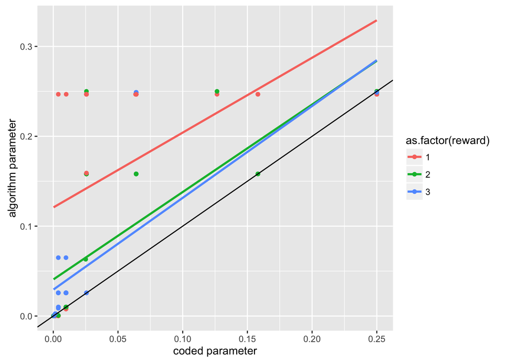

```r
ggplot(kirby.reward.output, aes(x = parameter, y = parameter.algorithm,color = as.factor(reward))) +
  geom_point() + geom_smooth(method = "lm", se=FALSE)+labs(x="coded parameter", y="algorithm parameter")+geom_abline(slope=1)
```

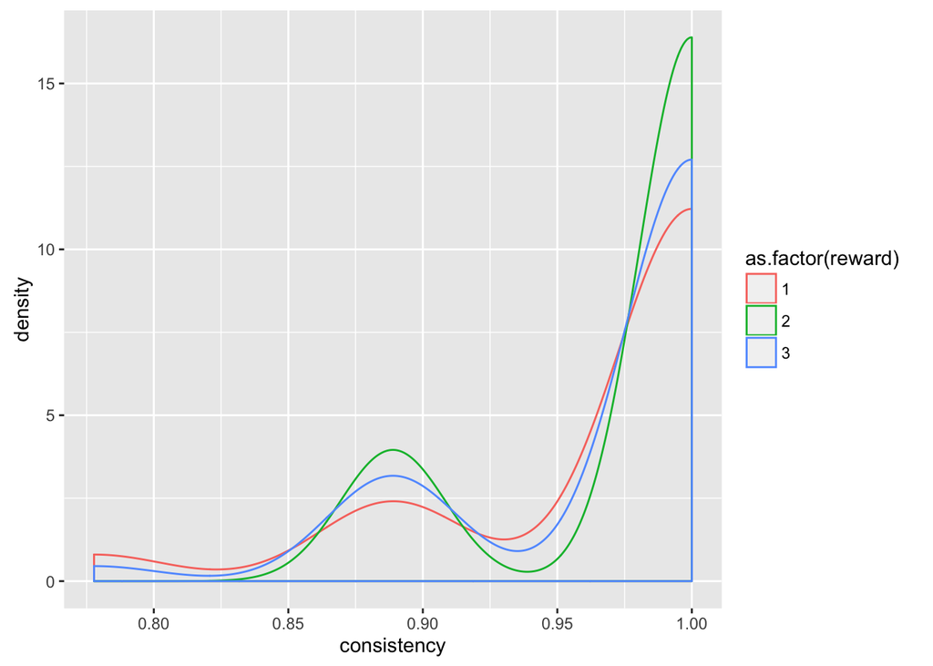

```r
ggplot(kirby.reward.output, aes(x=consistency, color=as.factor(reward)))+geom_density()
```

```r
# checking how well script output matches kirby et al. 1999

kirby.overall.output<-kirby.test %>% group_by(worker_id) %>% summarise(delayed_freq=sum(key_press-1)/n()) %>% left_join(kirby.overall.output, by="worker_id")

with(kirby.overall.output, cor(parameter,delayed_freq)) # check correlation between parameter and delayed frequency
```

```
## [1] -0.762946
```

```r
summary(lm(delayed_freq~log(parameter),data=kirby.overall.output)) # check how parameter affects delay
```

```
##
## Call:
## lm(formula = delayed_freq ~ log(parameter), data = kirby.overall.output)
##
## Residuals:
##       Min        1Q    Median        3Q       Max
## -0.083380 -0.015671 -0.006423  0.027732  0.137961
##
## Coefficients:
##                 Estimate Std. Error t value Pr(>|t|)
## (Intercept)    -0.091652   0.018926  -4.843 2.75e-05 ***
## log(parameter) -0.117910   0.004109 -28.698  < 2e-16 ***
## ---
## Signif. codes:  0 '***' 0.001 '**' 0.01 '*' 0.05 '.' 0.1 ' ' 1
##
## Residual standard error: 0.04677 on 34 degrees of freedom
## Multiple R-squared:  0.9604, Adjusted R-squared:  0.9592
## F-statistic: 823.6 on 1 and 34 DF,  p-value: < 2.2e-16
```

```r
kirby.reward.output<-kirby.test %>% group_by(worker_id, reward) %>% summarise(delayed_freq=sum(key_press-1)/n()) %>% left_join(kirby.reward.output, by=c("worker_id","reward"))

summary(lme(delayed_freq~log(parameter), random= ~ 1|as.factor(reward),data=kirby.reward.output)) # check parameter effects on delay, while controlling for different reward values
```

```
## Linear mixed-effects model fit by REML
##  Data: kirby.reward.output
##         AIC       BIC   logLik
##   -382.1905 -371.5367 195.0952
##
## Random effects:
##  Formula: ~1 | as.factor(reward)
##          (Intercept)   Residual
## StdDev: 1.095588e-06 0.03652586
##
## Fixed effects: delayed_freq ~ log(parameter)
##                     Value   Std.Error  DF   t-value p-value
## (Intercept)    -0.1415376 0.008690936 104 -16.28565       0
## log(parameter) -0.1261397 0.001840256 104 -68.54466       0
##  Correlation:
##                (Intr)
## log(parameter) 0.915
##
## Standardized Within-Group Residuals:
##         Min          Q1         Med          Q3         Max
## -3.13651955 -0.14641340  0.06878452  0.45160688  3.48826241
##
## Number of Observations: 108
## Number of Groups: 3
```

```r
kirby.reward.output %>% group_by(reward) %>% summarise(cor.parameter.choice=cor(parameter,delayed_freq))
```

```
## # A tibble: 3 × 2
##   reward cor.parameter.choice
##    <dbl>                <dbl>
## 1      1           -0.7965427
## 2      2           -0.7446234
## 3      3           -0.7677303
```

```r
summary(lme(log(parameter)~as.factor(reward), random= ~ 1|worker_id,data=kirby.reward.output)) # checking magnitude effects, while controlling for different participants and their repeated trials with different reward values.
```

```
## Linear mixed-effects model fit by REML
##  Data: kirby.reward.output
##        AIC     BIC    logLik
##   357.3352 370.605 -173.6676
##
## Random effects:
##  Formula: ~1 | worker_id
##         (Intercept)  Residual
## StdDev:    1.743349 0.7470368
##
## Fixed effects: log(parameter) ~ as.factor(reward)
##                        Value Std.Error DF    t-value p-value
## (Intercept)        -3.835405 0.3161105 70 -12.133114  0.0000
## as.factor(reward)2 -0.502448 0.1760783 70  -2.853548  0.0057
## as.factor(reward)3 -0.949103 0.1760783 70  -5.390234  0.0000
##  Correlation:
##                    (Intr) as.()2
## as.factor(reward)2 -0.279
## as.factor(reward)3 -0.279  0.500
##
## Standardized Within-Group Residuals:
##         Min          Q1         Med          Q3         Max
## -1.82905449 -0.59419548 -0.04631312  0.59682397  2.37995606
##
## Number of Observations: 108
## Number of Groups: 36
```

First off, it seems that the parameter estimates for the algorithm do not match up perfectly with the parameter estimates from the kirby script that I ran. Looking at a plot of both estimates, it seems that overall the kirby script estimates lower parameters, whereas the algorithm estimates higher ones. In addition, the algorithm uses rounded estimates compared to mine.

Looking at the consistencies, the algorithm’s percent match with each parameter does not follow a skewed curve to the right, whereas my script does show this. I believe the correct script should output a density of consistencies that lean towards the right tail where parameter estimates should correctly predict at least 80-100% of choices.

The discrepancies may be due to how the algorithm is coded and how Gray et al. calculated the parameters/consistencies. Regardless of how the algorithm output compares to the Kirby script, it seems that the Kirby script is producing results similar to what was found in Kirby et al. 1999. First off, there is a very strong negative correlation between percent of delayed choices with the parameter estimate. Second, there is a negative effect of parameter size on percent of delayed choices, controlling for reward size. And third, there seems to be a significantly negative effect of reward on parameter sizes.